# HIV Infection Analysis Dimension Reduction of DMSO, SAHA and PMA Datasets

## QUESTION 9 - Final interpretation

### 9.1 UMAP data preparation

```r
common_samples <- rownames(umap_coords_norm)

# PCA Data - SIN replicate
df_pca <- data.frame(
  Cell      = common_samples,
  Dim1      = sc_norm[common_samples, "PC1"],
  Dim2      = sc_norm[common_samples, "PC2"],
  Method    = "PCA",
  group     = metadata[common_samples, "group"],
  cell_type = metadata[common_samples, "cell_type"],
  treatment = metadata[common_samples, "treatment"],
  stringsAsFactors = FALSE
)

# t-SNE Data - SIN replicate
df_tsne <- data.frame(
  Cell      = common_samples,
  Dim1      = df_tsne_final[common_samples, "tSNE1"],
  Dim2      = df_tsne_final[common_samples, "tSNE2"],
  Method    = "t-SNE",
  group     = metadata[common_samples, "group"],
  cell_type = metadata[common_samples, "cell_type"],
  treatment = metadata[common_samples, "treatment"],
  stringsAsFactors = FALSE
)

# UMAP Data - SIN replicate
df_umap <- data.frame(
  Cell      = common_samples,
  Dim1      = umap_coords_norm[common_samples, "UMAP1"],
  Dim2      = umap_coords_norm[common_samples, "UMAP2"],
  Method    = "UMAP",
  group     = metadata[common_samples, "group"],
  cell_type = metadata[common_samples, "cell_type"],
  treatment = metadata[common_samples, "treatment"],
  stringsAsFactors = FALSE
)

df_long <- dplyr::bind_rows(df_pca, df_tsne, df_umap)
df_long$Method <- factor(df_long$Method, levels = c("PCA", "t-SNE", "UMAP"))
```

### 9.2 Comparison ploting alternatives

#### 9.2.1 Alternative 1

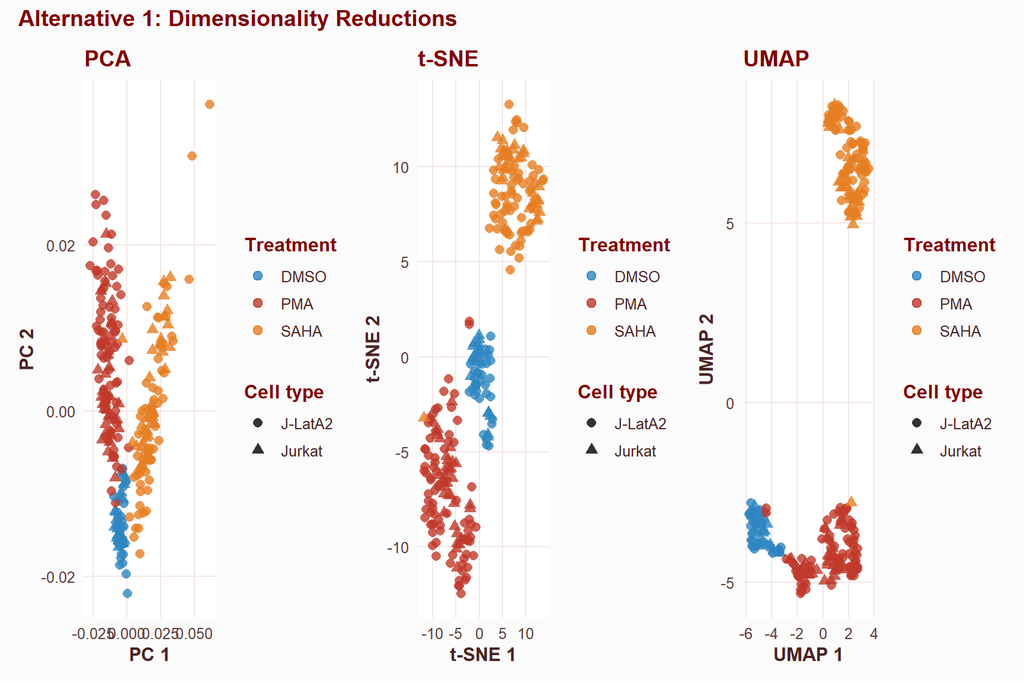

```r
alt1_pca <- ggplot(df_pca, aes(x = Dim1, y = Dim2, colour = treatment, shape = cell_type)) +
  geom_point(size = 2.5, alpha = 0.8) +
  scale_colour_manual(values = treatment_colours, name = "Treatment") +
  scale_shape_manual(values = cell_shapes, name = "Cell type") +
  labs(title = "PCA", x = "PC 1", y = "PC 2") +
  theme_hospital_bio() +
  theme(legend.position = "none")

alt1_tsne <- ggplot(df_tsne, aes(x = Dim1, y = Dim2, colour = treatment, shape = cell_type)) +
  geom_point(size = 2.5, alpha = 0.8) +
  scale_colour_manual(values = treatment_colours, name = "Treatment") +
  scale_shape_manual(values = cell_shapes, name = "Cell type") +
  labs(title = "t-SNE", x = "t-SNE 1", y = "t-SNE 2") +
  theme_hospital_bio() +
  theme(legend.position = "none")

alt1_umap <- ggplot(df_umap, aes(x = Dim1, y = Dim2, colour = treatment, shape = cell_type)) +
  geom_point(size = 2.5, alpha = 0.8) +
  scale_colour_manual(values = treatment_colours, name = "Treatment") +
  scale_shape_manual(values = cell_shapes, name = "Cell type") +
  labs(title = "UMAP", x = "UMAP 1", y = "UMAP 2") +
  theme_hospital_bio() +
  theme(legend.position = "right")

alt1_combined <- (alt1_pca | alt1_tsne | alt1_umap) +
  plot_annotation(title = "Alternative 1: Dimensionality Reductions",
                  theme = theme(plot.title = element_text(size = 14, face = "bold"))) &
  theme_hospital_bio()

print(alt1_combined)
```

#### 9.2.2 Alternative 2

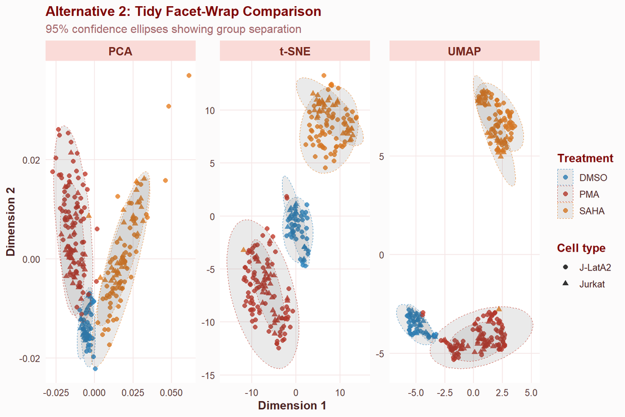

```r
alt2_facet_plot <- ggplot(df_long, aes(x = Dim1, y = Dim2, colour = treatment, shape = cell_type)) +
  geom_point(alpha = 0.8, size = 2, stroke = 0.5) +
  stat_ellipse(geom = "polygon", alpha = 0.10, level = 0.95, linetype = "dashed", linewidth = 0.35) +
  facet_wrap(~ Method, scales = "free", nrow = 1) +
  scale_colour_manual(values = treatment_colours, name = "Treatment") +
  scale_shape_manual(values = cell_shapes, name = "Cell type") +
  labs(
    title = "Alternative 2: Tidy Facet-Wrap Comparison",
    subtitle = "95% confidence ellipses showing group separation",
    x = "Dimension 1", y = "Dimension 2"
  ) +
  theme_hospital_bio() +
  theme(plot.title = element_text(face = "bold", size = 14),
        strip.text = element_text(face = "bold", size = 12),
        legend.position = "right")

print(alt2_facet_plot)
```

#### 9.2.3 Alternative 3

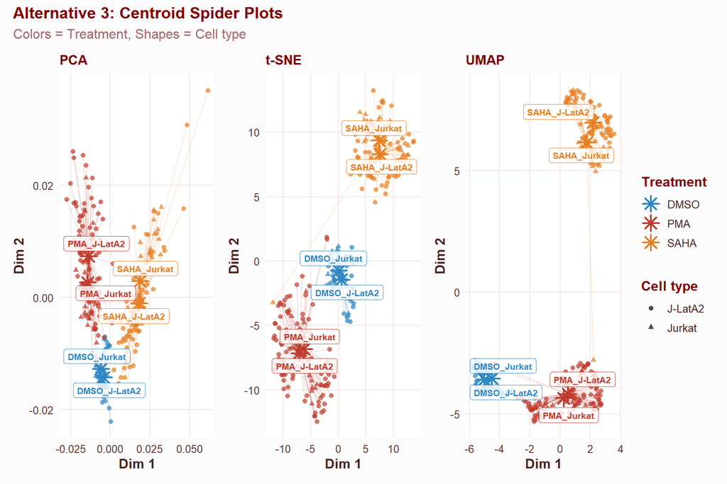

```r
compute_centroids <- function(df) {
  df |> dplyr::group_by(treatment, cell_type) |>
    dplyr::summarise(centroid_x = mean(Dim1, na.rm = TRUE),
                     centroid_y = mean(Dim2, na.rm = TRUE),
                     .groups = "drop") |>
    dplyr::mutate(group = paste(treatment, cell_type, sep = "_"))
}

build_spider_plot <- function(df, method_label) {
  centroids_df <- compute_centroids(df)
  spider_df <- df |> dplyr::left_join(centroids_df, by = c("treatment", "cell_type"))

  ggplot() +
    geom_segment(data = spider_df,
                 aes(x = Dim1, y = Dim2, xend = centroid_x, yend = centroid_y, colour = treatment),
                 alpha = 0.3, linewidth = 0.3) +
    geom_point(data = spider_df, aes(x = Dim1, y = Dim2, colour = treatment, shape = cell_type),
               size = 1.5, alpha = 0.7) +
    geom_point(data = centroids_df, aes(x = centroid_x, y = centroid_y, colour = treatment),
               shape = 8, size = 4, stroke = 1.2) +
    ggrepel::geom_label_repel(data = centroids_df,
                              aes(x = centroid_x, y = centroid_y, label = group, colour = treatment),
                              size = 2.8, fontface = "bold", fill = "white", alpha = 0.8, show.legend = FALSE) +
    scale_colour_manual(values = treatment_colours, name = "Treatment") +
    scale_shape_manual(values = cell_shapes, name = "Cell type") +
    labs(title = method_label, x = "Dim 1", y = "Dim 2") +
    theme_hospital_bio() +
    theme(plot.title = element_text(face = "bold", size = 12))
}

alt3_pca   <- build_spider_plot(df_pca, "PCA") + theme(legend.position = "none")
alt3_tsne  <- build_spider_plot(df_tsne, "t-SNE") + theme(legend.position = "none")
alt3_umap  <- build_spider_plot(df_umap, "UMAP") + theme(legend.position = "right")

alt3_combined <- (alt3_pca | alt3_tsne | alt3_umap) +
  plot_annotation(title = "Alternative 3: Centroid Spider Plots",
                  subtitle = "Colors = Treatment, Shapes = Cell type")
print(alt3_combined)
```

We designed these centroid spider networks to explicitly map the internal geometry and spatial spread of each distinct biological subgroup. By anchoring every single cell to its calculated group centroid, we can immediately spot the intra-cluster variance. In the non-linear projections, the exceptionally short “spider legs” visually confirm the high density of the clusters and show us exactly where the Jurkat and J-LatA2 populations spatially diverge within the broader drug conditions.